# Assignment 3

```r
nycbikes18 <- read_csv("data/2018-citibike-tripdata.csv",
  locale = locale(tz = "America/New_York"))
```

## Q1: Web scraping

```r
citiBikePricingLink <- "https://www.citibikenyc.com/pricing"
citiBikePage <- read_html(citiBikePricingLink)
plan <- citiBikePage %>%
  html_elements("h2.type-alpha--l")%>%
  html_text(trim=TRUE) %>%
  head(3)
price <- citiBikePage %>%
  html_elements("p.type-alpha--m") %>%
  html_text(trim=TRUE)
minutes <- citiBikePage %>%
  html_elements("p.type-alpha--s") %>%
  html_text(trim=TRUE) %>%
  head(3)
table <- tibble(Plan = plan, Price = price, Minutes = minutes)
kable(table)
```

| Plan | Price | Minutes |
| --- | --- | --- |
| Single Ride | $3.50/trip | one ride up to 30 minutes on a Classic bike. |
| Day Pass | $15/day | unlimited 30-minute rides in a 24-hour period on a Classic bike. |
| Annual Membership | $15*/month | unlimited 45-minute rides on a Classic bike. |

## Q2: Critique

After comparing with analyses of the “citibike nyc” data found on other reports found, I noticed that the age groups were equally grouped into age ranges of approximately 10 years (e.g 35-44 years), whereas for the data given in Assignment 2 Question 4, the age groups vary from range 10 years (e.g 0-14 years, 15-24 years) to 20 years(e.g 25-44 years, 45-64 years.

Reference:

https://medium.com/@clairekeser/using-nyc-citi-bike-data-to-help-bike-enthusiasts-find-their-mates-70a661c098f1#dc54

(Refer to the section: “Riders per Age Group”)

## Q3: Polishing

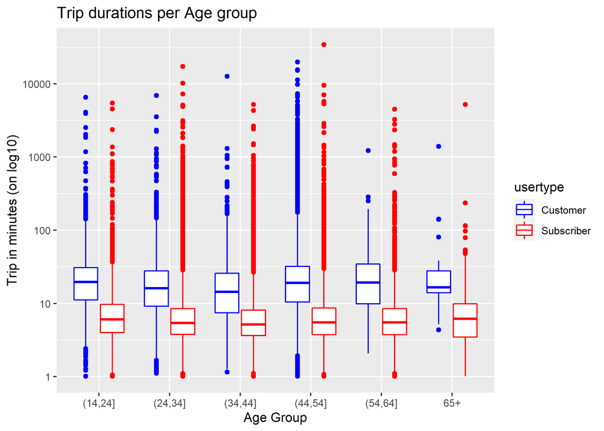

```r
age_brk <- c(0, 14, 24, 34, 44, 54, 64, Inf)
nycbikes18_age <- nycbikes18 %>%
  mutate(
    tripduration = tripduration / 60,
    birth_year = case_when(birth_year < 1900 ~ NA_real_, TRUE ~ birth_year),
    age = 2018 - birth_year,
    age_group = cut(age, age_brk, include.lowest = TRUE),
    age_group = fct_recode(age_group, "65+" = "(64,Inf]")
  )
p3 <- nycbikes18_age %>%
  filter(is.na(age_group) == FALSE) %>%
  ggplot(aes(age_group, tripduration)) +
  geom_boxplot(aes(colour = usertype)) +
  scale_y_log10() +
  scale_color_manual(values=c("blue", "red")) +
  labs(title = "Trip durations per Age group", x = "Age Group", y = "Trip in minutes (on log10)")
p3
```

The plot I chose to improve is the boxplot from question 5 of Assignment 2. I decided to improve the following factors: - Change the age group ranges to 10 years, as discussed in the previous question (Question 2 Assignment 3) - Filtering out the N/A missing values for the ages - Adding a title to the plot (“Trip durations per Age group”) - Changing the colours to “red” and “blue” for a clearer contrast

After improving the above factors, I found that the median trip duration times for the customers were higher than that of subscribers over all age groups.

## Q4: Exploration

[figure not shown]

This plot shows the overall trends in the hours that the users start using the bikes. There is a clear peak in starting hour for the users who are subscribers at approximately 8 am and 6 pm, which are the commuting hours for most people. In comparsion to this, there does not seem to be a clear trend for the starting hour of the users who are customers. I believe the reason for this is because, subscribers will always use the bikes in a specific time, whereas the customers will only use the bikes when needed, resulting in a variety of starting hours.

## Appendix

```r
plot <- nycbikes18 %>%
  mutate(start = hour(starttime), end = hour(stoptime)) %>%
  ggplot(aes(start, color = usertype)) +
  geom_freqpoly(binwidth = 1) +
  scale_x_continuous(breaks=seq(0,23,1)) +
  coord_cartesian(xlim = c(1, 22)) +
  labs(title= "Starting hour of users", x= "starting hour", y= "number of users")
plot
```